# Análisis de series temporales: temperatura media mensual de Puerto Madryn (2010–2025)

Unidad 1 · Naturaleza, EDA, autocorrelación, diferenciación y estacionariedad

## 1 Preparación del entorno y obtención de los datos

La serie se obtuvo a través de una consulta a la API histórica de Open-Meteo, utilizando la temperatura media diaria a 2 m del modelo ERA5 para las coordenadas aproximadas de Puerto Madryn (−42,77; −65,04). Se promediaron los días de cada mes para construir la serie mensual. Se trata de datos de reanálisis, no de mediciones directas de una estación meteorológica.

```r
url <- paste0(
  "https://archive-api.open-meteo.com/v1/archive?",
  "latitude=-42.77&longitude=-65.04",
  "&start_date=2010-01-01&end_date=2025-12-31",
  "&daily=temperature_2m_mean",
  "&timezone=America%2FArgentina%2FCatamarca&models=era5"
)

respuesta <- jsonlite::fromJSON(url)

if (!is.null(respuesta$error) && isTRUE(respuesta$error)) {
  stop(respuesta$reason)
}

datos_diarios <- tibble(
  fecha = as.Date(respuesta$daily$time),
  temperatura = respuesta$daily$temperature_2m_mean
)

datos_mensuales <- datos_diarios |>
  mutate(mes = floor_date(fecha, "month")) |>
  group_by(mes) |>
  summarise(
    dias_observados = sum(!is.na(temperatura)),
    temperatura = if (all(is.na(temperatura))) {
      NA_real_
    } else {
      mean(temperatura, na.rm = TRUE)
    },
    .groups = "drop"
  ) |>
  rename(fecha = mes) |>
  arrange(fecha)

glimpse(datos_mensuales)
```

```
Rows: 192
Columns: 3
$ fecha           <date> 2010-01-01, 2010-02-01, 2010-03-01, 2010-04-01, 2010-…
$ dias_observados <int> 31, 28, 31, 30, 31, 30, 31, 31, 30, 31, 30, 31, 31, 28…
$ temperatura     <dbl> 23.903226, 20.210714, 18.970968, 14.550000, 12.183871,…
```

### 1.1 Control de calidad y regularidad

Se revisan los valores faltantes, los meses ausentes y la cantidad de días registrados en cada mes.

```r
nrow(datos_mensuales)
```

```
[1] 192
```

```r
colSums(is.na(datos_mensuales))
```

```
          fecha dias_observados     temperatura
              0               0               0
```

```r
fechas_esperadas <- seq.Date(
  as.Date("2010-01-01"),
  as.Date("2025-12-01"),
  by = "month"
)

setdiff(fechas_esperadas, datos_mensuales$fecha)
```

```
Date of length 0
```

```r
datos_mensuales |>
  mutate(dias_esperados = days_in_month(fecha)) |>
  filter(dias_observados != dias_esperados)
```

```
# A tibble: 0 × 4
# ℹ 4 variables: fecha <date>, dias_observados <int>, temperatura <dbl>,
#   dias_esperados <int>
```

```r
summary(datos_mensuales$temperatura)
```

```
   Min. 1st Qu.  Median    Mean 3rd Qu.    Max.
  5.794  10.246  15.127  15.178  20.238  24.055
```

**Interpretación.** La serie contiene 192 observaciones mensuales, correspondientes al período entre enero de 2010 y diciembre de 2025. El control de calidad nos permitió verificar que no existen meses ausentes, valores faltantes ni diferencias entre la cantidad de días observados y los días esperados de cada mes. Por lo tanto, disponemos de una serie temporal regular y completa, con frecuencia mensual.

La temperatura media del período fue de 15,18 °C, con una mediana de 15,13 °C y valores comprendidos entre 5,79 °C y 24,06 °C. Estas medidas describen la distribución general de las temperaturas, aunque todavía no nos permiten identificar sus patrones temporales.

En consecuencia, la serie reúne las condiciones básicas de integridad y regularidad necesarias para avanzar hacia el análisis exploratorio de sus componentes temporales.

## 2 Naturaleza de la serie

### 2.1 Visualización inicial y reconocimiento de componentes

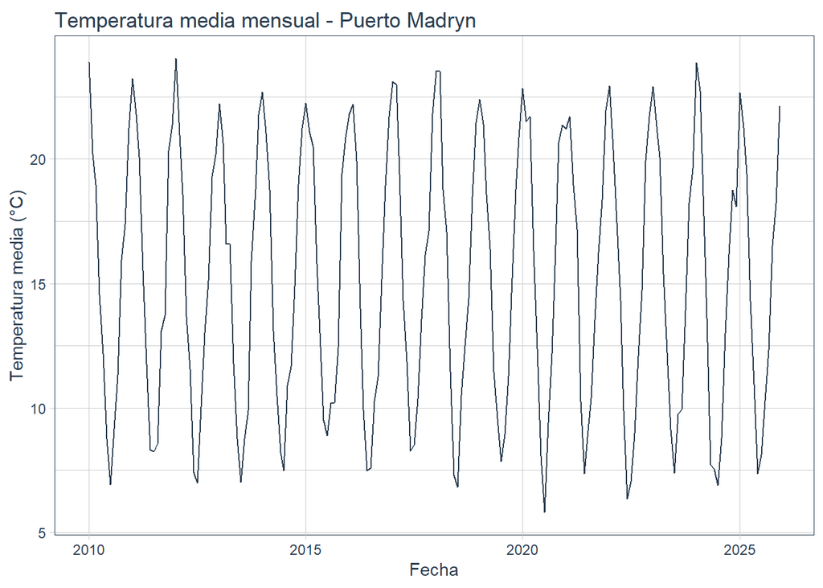

```r
datos_mensuales |>
  plot_time_series(
    .date_var    = fecha,
    .value       = temperatura,
    .title       = "Temperatura media mensual - Puerto Madryn",
    .x_lab       = "Fecha",
    .y_lab       = "Temperatura media (°C)",
    .smooth      = FALSE,
    .interactive = FALSE
  )
```

**Interpretación.** La serie de temperatura media mensual de Puerto Madryn presenta una sucesión regular de máximos durante los meses del verano austral y mínimos durante el invierno, comportamiento que se repite a lo largo de los 16 años analizados.

Las oscilaciones estacionales mantienen una amplitud relativamente estable, aunque existen diferencias entre los valores alcanzados en distintos años. Esto sugiere inicialmente una estructura estacional de tipo aditivo.

En cuanto a la evolución de largo plazo, no se identifica visualmente una tendencia creciente o decreciente sostenida durante todo el período. Sin embargo, esta observación no permite concluir que la serie sea estacionaria aun, ya que presenta una marcada estructura estacional y dependencia temporal que deberán examinarse posteriormente.

Es decir, el gráfico permite reconocer una estacionalidad anual predominante y fluctuaciones interanuales, lo que justifica avanzar hacia una descomposición de la serie para estudiar sus componentes por separado.

## 3 Análisis exploratorio de datos (EDA)

### 3.1 Descomposición STL

STL separa la serie en un componente de tendencia-ciclo, un componente estacional y un componente residual. Para la serie mensual se utiliza una periodicidad de 12 meses y una ventana de tendencia de 25 observaciones.

```r
datos_mensuales |>
  plot_stl_diagnostics(
    .date_var    = fecha,
    .value       = temperatura,
    .frequency   = 12,
    .trend       = 25,
    .feature_set = c(
      "observed",
      "season",
      "trend",
      "remainder"
    )
  )
```

[interactive chart not shown]

**Interpretación.** La descomposición STL nos permite distinguir:

El componente estacional, que presenta oscilaciones anuales regulares y de amplitud relativamente estable a lo largo del período 2010–2025. Esto confirma que la estacionalidad constituye una característica predominante de la serie y respalda la hipótesis inicial de una estructura aditiva.

El componente de tendencia-ciclo nos muestra fluctuaciones suaves alrededor del nivel medio de la serie, sin evidenciar una dirección creciente o decreciente sostenida durante todo el período.

Por su parte, el componente residual presenta fluctuaciones alrededor de cero, con algunos desvíos puntuales respecto del comportamiento explicado por la tendencia-ciclo y la estacionalidad. Sin embargo, esta característica no nos permite afirmar que los residuos constituyan ruido blanco, ya que debemos comprobar también la ausencia de autocorrelación temporal.

En conjunto, la descomposición evidencia que la mayor parte de las oscilaciones observadas responde a un patrón estacional anual. Este resultado justifica que profundicemos el análisis exploratorio mediante la comparación de las temperaturas correspondientes a los distintos meses del año.

### 3.2 Diagnóstico estacional

Se comparan las temperaturas de cada mes del año mediante diagramas de caja.

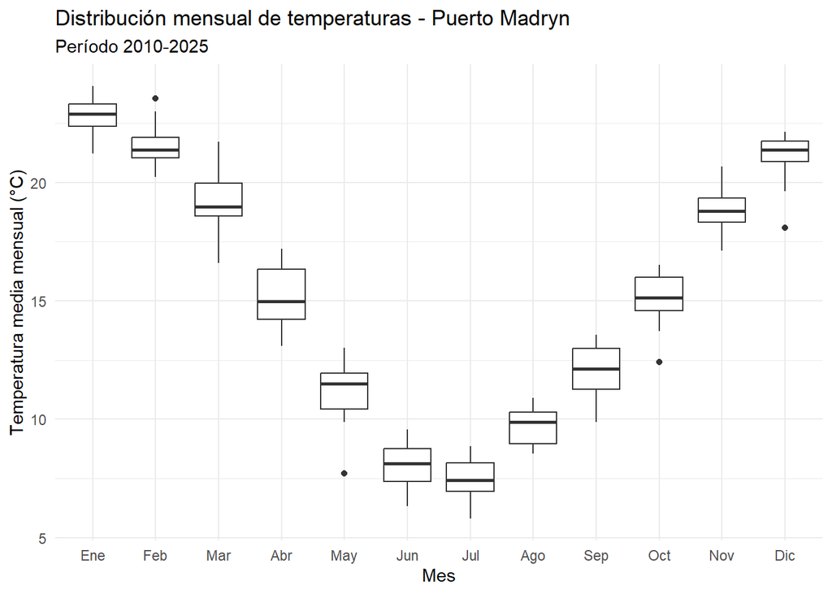

```r
datos_estacionales <- datos_mensuales |>
  mutate(
    mes = factor(
      month(fecha),
      levels = 1:12,
      labels = c(
        "Ene", "Feb", "Mar", "Abr",
        "May", "Jun", "Jul", "Ago",
        "Sep", "Oct", "Nov", "Dic"
      )
    )
  )

ggplot(datos_estacionales, aes(x = mes, y = temperatura)) +
  geom_boxplot() +
  labs(
    title = "Distribución mensual de temperaturas - Puerto Madryn",
    subtitle = "Período 2010-2025",
    x = "Mes",
    y = "Temperatura media mensual (°C)"
  ) +
  theme_minimal()
```

**Interpretación.** Los diagramas de caja muestran diferencias marcadas entre las distribuciones de temperatura media de los distintos meses del año, lo que confirma la presencia de un patrón estacional bien definido.

Las medianas más elevadas corresponden a los meses de verano, especialmente enero y febrero. Las más bajas se registran durante el invierno, principalmente en junio, julio y agosto. Entre ambos períodos se observa una transición gradual de las temperaturas durante el otoño y la primavera.

La dispersión de las temperaturas dentro de cada mes refleja la variabilidad interanual. Esta variabilidad no es uniforme en todos los meses, aunque las diferencias entre las medianas mensuales predominan.

Asimismo, observamos algunos valores atípicos en las distribuciones mensuales, pero no necesariamente constituyen anomalías temporales, ya que su identificación requiere considerar también la tendencia y la estructura estacional de la serie.

En general, los diagramas de caja permiten confirmar que las diferencias sistemáticas entre los meses constituyen una fuente importante de variabilidad de la temperatura.

### 3.3 Diagnóstico de anomalías

En series temporales, una anomalía es una observación que se aparta del patrón esperado de tendencia y estacionalidad. Se aplica el diagnóstico sobre la serie completa como parte del análisis exploratorio.

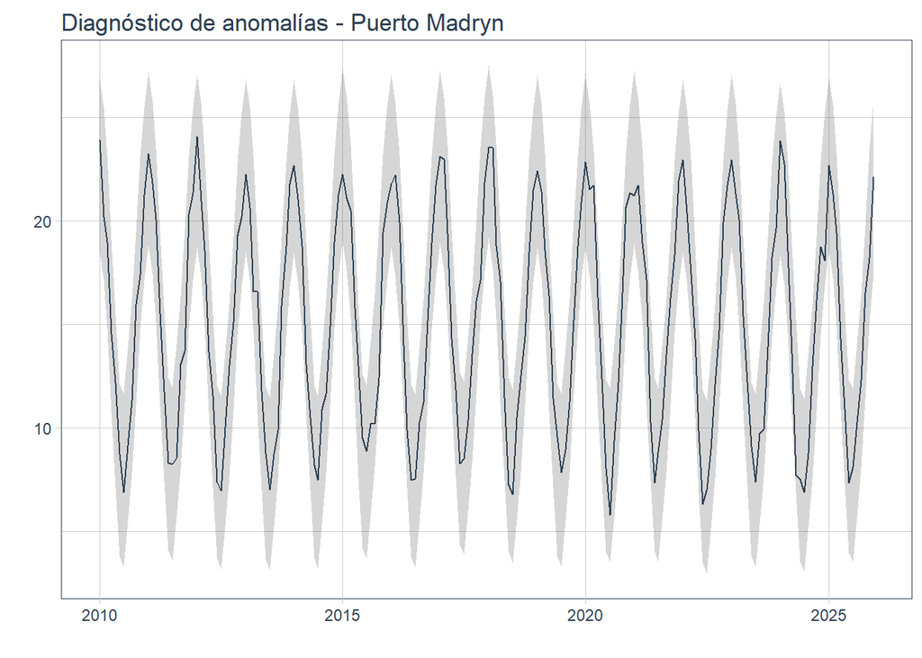

```r
datos_mensuales |>
  plot_anomaly_diagnostics(
    .date_var    = fecha,
    .value       = temperatura,
    .frequency   = 12,
    .trend       = 25,
    .title       = "Diagnóstico de anomalías - Puerto Madryn",
    .interactive = FALSE
  )
```

```r
anomalias <- datos_mensuales |>
  tk_anomaly_diagnostics(
    .date_var  = fecha,
    .value     = temperatura,
    .frequency = 12,
    .trend     = 25
  )

anomalias |>
  filter(anomaly == "Yes") |>
  arrange(desc(abs(remainder)))
```

```
# A tibble: 0 × 11
# ℹ 11 variables: fecha <date>, observed <dbl>, season <dbl>, trend <dbl>,
#   remainder <dbl>, seasadj <dbl>, remainder_l1 <dbl>, remainder_l2 <dbl>,
#   anomaly <chr>, recomposed_l1 <dbl>, recomposed_l2 <dbl>
```

**Interpretación.** El diagnóstico no identificó observaciones anómalas durante el período 2010–2025, de acuerdo con el procedimiento y los parámetros que utilizamos.

Esto indica que las fluctuaciones observadas no superaron los criterios de detección establecidos por el método, una vez considerada la estructura de tendencia y estacionalidad de la serie.

Es importante distinguir este resultado de los posibles valores atípicos identificados en los diagramas de caja. Un valor relativamente extremo para un determinado mes no necesariamente constituye una anomalía temporal, ya que ambos procedimientos utilizan criterios diferentes.

La ausencia de anomalías detectadas no implica que no hayan ocurrido episodios meteorológicos excepcionales. El análisis se realiza sobre promedios mensuales, que pueden suavizar variaciones extremas registradas en días individuales.

En consecuencia, no se identifican observaciones que requieran un tratamiento particular por anomalía en esta etapa del análisis exploratorio.

### 3.4 Transformaciones consideradas

La transformación logarítmica no se aplica automáticamente a temperaturas expresadas en °C. En cambio, más adelante se estudian la primera diferencia y la diferencia estacional como herramientas para evaluar la estacionariedad y la persistencia temporal.

## 4 Autocorrelación, diferenciación y estacionariedad

### 4.1 Función de autocorrelación de la serie original

La ACF mide la relación lineal entre la serie y sus propios valores pasados. Como la serie es mensual y presenta periodicidad anual, resulta especialmente importante observar los rezagos múltiplos de 12.

Examinamos los primeros 48 rezagos de la función de autocorrelación (ACF), equivalentes a cuatro años, para identificar la dependencia temporal y reconocer los patrones asociados con la estacionalidad anual.

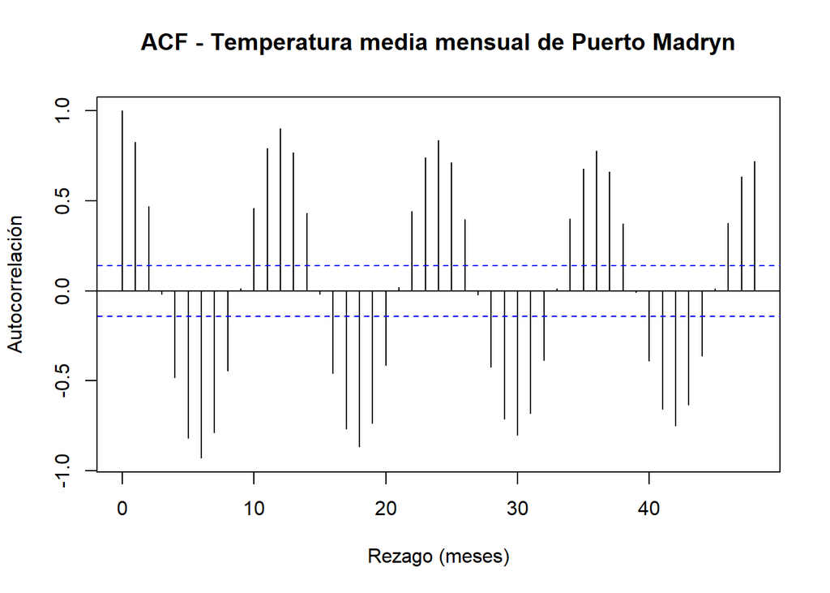

```r
#| label: acf-serie-original
#| fig-width: 9
#| fig-height: 4

acf(
  datos_mensuales$temperatura,
  lag.max = 48,
  main = "ACF - Temperatura media mensual de Puerto Madryn",
  xlab = "Rezago (meses)",
  ylab = "Autocorrelación"
)
```

**Interpretación.** La función de autocorrelación (ACF) de la temperatura media mensual de Puerto Madryn muestra una estructura de dependencia temporal marcada, caracterizada por oscilaciones que se repiten aproximadamente cada 12 meses.

En el rezago 1 observamos una autocorrelación positiva elevada, cercana a 0,82, lo que nos indica una fuerte asociación lineal entre las temperaturas de meses consecutivos.

También identificamos autocorrelaciones positivas importantes en los rezagos 12, 24, 36 y 48, correspondientes a uno, dos, tres y cuatro años. Esto es consistente con la estacionalidad anual, ya que las temperaturas de un determinado mes tienden a relacionarse positivamente con las del mismo mes de años anteriores.

Por otra parte, observamos autocorrelaciones negativas pronunciadas en los rezagos 6, 18, 30 y 42. Este comportamiento es coherente con la alternancia entre las estaciones cálidas y frías del año.

Numerosas autocorrelaciones superan las bandas de referencia del gráfico, lo que evidencia una estructura de dependencia temporal incompatible con la ausencia de autocorrelación característica del ruido blanco.

Sin embargo, la presencia de autocorrelación no nos permite determinar por sí sola si la serie presenta una raíz unitaria o si es estacionaria. Para profundizar este diagnóstico, se aplicará posteriormente el test de Dickey-Fuller aumentado (ADF).

### 4.2 Test de Dickey-Fuller aumentado (ADF) en niveles

El test de Dickey-Fuller aumentado (ADF) permite contrastar la presencia de una raíz unitaria ordinaria en una serie temporal.

La hipótesis nula es:

$$H_0: \gamma = 0$$

frente a la hipótesis alternativa:

$$H_1: \gamma < 0$$

donde $\gamma$ es el coeficiente asociado con el nivel rezagado de la serie en la regresión auxiliar del test ADF.

La hipótesis nula corresponde a la presencia de una raíz unitaria ordinaria. La alternativa corresponde a un proceso estacionario alrededor de los componentes determinísticos incluidos en la especificación.

Siguiendo el procedimiento de clase, se calculan las tres especificaciones disponibles en `ur.df()`: con constante y tendencia (`trend`), con constante (`drift`) y sin términos determinísticos (`none`).

```r
adf_original_trend <- datos_mensuales |>
  pull(temperatura) |>
  ur.df(
    type       = "trend",
    lags       = 12,
    selectlags = "AIC"
  )

adf_original_drift <- datos_mensuales |>
  pull(temperatura) |>
  ur.df(
    type       = "drift",
    lags       = 12,
    selectlags = "AIC"
  )

adf_original_none <- datos_mensuales |>
  pull(temperatura) |>
  ur.df(
    type       = "none",
    lags       = 12,
    selectlags = "AIC"
  )

summary(adf_original_trend)
```

```
###############################################
# Augmented Dickey-Fuller Test Unit Root Test #
###############################################

Test regression trend


Call:
lm(formula = z.diff ~ z.lag.1 + 1 + tt + z.diff.lag)

Residuals:
    Min      1Q  Median      3Q     Max
-3.4865 -0.6231 -0.0578  0.7601  2.5203

Coefficients:
              Estimate Std. Error t value Pr(>|t|)
(Intercept)  14.000136   4.045718   3.460 0.000686 ***
z.lag.1      -0.915394   0.264256  -3.464 0.000678 ***
tt           -0.001063   0.001709  -0.622 0.535057
z.diff.lag1   0.251695   0.250137   1.006 0.315778
z.diff.lag2   0.371915   0.228491   1.628 0.105497
z.diff.lag3   0.174077   0.209295   0.832 0.406763
z.diff.lag4   0.047496   0.190708   0.249 0.803631
z.diff.lag5  -0.061837   0.169257  -0.365 0.715320
z.diff.lag6  -0.176514   0.145708  -1.211 0.227465
z.diff.lag7  -0.207101   0.125697  -1.648 0.101333
z.diff.lag8  -0.205253   0.107943  -1.901 0.058981 .
z.diff.lag9  -0.335241   0.092913  -3.608 0.000409 ***
z.diff.lag10 -0.419510   0.086549  -4.847 2.87e-06 ***
z.diff.lag11 -0.155102   0.076375  -2.031 0.043881 *
---
Signif. codes:  0 '***' 0.001 '**' 0.01 '*' 0.05 '.' 0.1 ' ' 1

Residual standard error: 1.159 on 165 degrees of freedom
Multiple R-squared:  0.8669,    Adjusted R-squared:  0.8564
F-statistic: 82.65 on 13 and 165 DF,  p-value: < 2.2e-16


Value of test-statistic is: -3.464 4.0015 6.0001

Critical values for test statistics:
      1pct  5pct 10pct
tau3 -3.99 -3.43 -3.13
phi2  6.22  4.75  4.07
phi3  8.43  6.49  5.47
```

```r
summary(adf_original_drift)
```

```
###############################################
# Augmented Dickey-Fuller Test Unit Root Test #
###############################################

Test regression drift


Call:
lm(formula = z.diff ~ z.lag.1 + 1 + z.diff.lag)

Residuals:
    Min      1Q  Median      3Q     Max
-3.5531 -0.6546 -0.0490  0.8050  2.4939

Coefficients:
             Estimate Std. Error t value Pr(>|t|)
(Intercept)  13.42661    3.93182   3.415 0.000802 ***
z.lag.1      -0.88473    0.25913  -3.414 0.000804 ***
z.diff.lag1   0.22468    0.24588   0.914 0.362155
z.diff.lag2   0.34746    0.22466   1.547 0.123870
z.diff.lag3   0.15125    0.20567   0.735 0.463115
z.diff.lag4   0.02704    0.18750   0.144 0.885497
z.diff.lag5  -0.07933    0.16659  -0.476 0.634554
z.diff.lag6  -0.19057    0.14368  -1.326 0.186542
z.diff.lag7  -0.21881    0.12405  -1.764 0.079577 .
z.diff.lag8  -0.21474    0.10666  -2.013 0.045702 *
z.diff.lag9  -0.34261    0.09198  -3.725 0.000268 ***
z.diff.lag10 -0.42459    0.08600  -4.937 1.92e-06 ***
z.diff.lag11 -0.15726    0.07615  -2.065 0.040479 *
---
Signif. codes:  0 '***' 0.001 '**' 0.01 '*' 0.05 '.' 0.1 ' ' 1

Residual standard error: 1.157 on 166 degrees of freedom
Multiple R-squared:  0.8666,    Adjusted R-squared:  0.8569
F-statistic: 89.83 on 12 and 166 DF,  p-value: < 2.2e-16


Value of test-statistic is: -3.4142 5.8307

Critical values for test statistics:
      1pct  5pct 10pct
tau2 -3.46 -2.88 -2.57
phi1  6.52  4.63  3.81
```

```r
summary(adf_original_none)
```

```
###############################################
# Augmented Dickey-Fuller Test Unit Root Test #
###############################################

Test regression none


Call:
lm(formula = z.diff ~ z.lag.1 - 1 + z.diff.lag)

Residuals:
     Min       1Q   Median       3Q      Max
-3.10707 -0.70094  0.00308  0.84555  2.57157

Coefficients:
               Estimate Std. Error t value Pr(>|t|)
z.lag.1      -5.007e-05  5.879e-03  -0.009  0.99322
z.diff.lag1  -5.774e-01  7.501e-02  -7.698 1.15e-12 ***
z.diff.lag2  -3.786e-01  7.486e-02  -5.057 1.11e-06 ***
z.diff.lag3  -5.141e-01  6.789e-02  -7.573 2.36e-12 ***
z.diff.lag4  -5.717e-01  6.850e-02  -8.347 2.54e-14 ***
z.diff.lag5  -6.019e-01  6.788e-02  -8.867 1.10e-15 ***
z.diff.lag6  -6.308e-01  6.543e-02  -9.640  < 2e-16 ***
z.diff.lag7  -5.788e-01  6.741e-02  -8.586 6.04e-15 ***
z.diff.lag8  -5.002e-01  6.832e-02  -7.322 9.84e-12 ***
z.diff.lag9  -5.619e-01  6.794e-02  -8.270 4.02e-14 ***
z.diff.lag10 -5.815e-01  7.498e-02  -7.756 8.25e-13 ***
z.diff.lag11 -2.374e-01  7.473e-02  -3.176  0.00178 **
---
Signif. codes:  0 '***' 0.001 '**' 0.01 '*' 0.05 '.' 0.1 ' ' 1

Residual standard error: 1.193 on 167 degrees of freedom
Multiple R-squared:  0.8572,    Adjusted R-squared:  0.8469
F-statistic: 83.53 on 12 and 167 DF,  p-value: < 2.2e-16


Value of test-statistic is: -0.0085

Critical values for test statistics:
      1pct  5pct 10pct
tau1 -2.58 -1.95 -1.62
```

**Interpretación.** El test de Dickey-Fuller aumentado (ADF) se aplicó a la serie original de temperatura media mensual de Puerto Madryn para evaluar la hipótesis nula de presencia de una raíz unitaria, considerando tres especificaciones de los componentes determinísticos:

En la especificación con constante y tendencia (`trend`), el estadístico tau3 fue -3,4640, inferior al valor crítico de -3,43 correspondiente al nivel de significación del 5 %. Por lo tanto, se rechaza la hipótesis nula de raíz unitaria en favor de la alternativa de estacionariedad alrededor de una tendencia determinística.

En la especificación con constante y sin tendencia (`drift`), el estadístico tau2 fue -3,4142, también inferior al valor crítico de -2,88 al 5 %. En consecuencia, se rechaza nuevamente la hipótesis nula de raíz unitaria, en este caso en favor de una alternativa estacionaria alrededor de una media constante.

Por el contrario, en la especificación sin constante ni tendencia (`none`), el estadístico tau1 fue -0,0085, superior al valor crítico de -1,95. Por lo tanto, no se rechaza la hipótesis nula. Sin embargo, esta especificación resulta poco adecuada para la serie original, dado que la temperatura presenta una media claramente distinta de cero.

En conjunto, las especificaciones con constante y con constante y tendencia proporcionan evidencia estadística contra la presencia de una raíz unitaria ordinaria al nivel de significación del 5 %. No obstante, estos resultados deben interpretarse con cautela debido a la marcada estacionalidad anual de la serie.

Es importante señalar que rechazar la hipótesis de raíz unitaria ordinaria no demuestra, por sí solo, que la serie original sea estacionaria en sentido amplio, ni descarta la existencia de componentes estacionales que requieran un tratamiento específico.

### 4.3 Diferenciación ordinaria y estacional

La primera diferencia se define como:

$$\Delta T_t = T_t - T_{t-1}$$

donde $T_t$ representa la temperatura media mensual en el período $t$.

Para una serie mensual también puede analizarse la diferencia estacional de orden 12:

$$\Delta_{12} T_t = T_t - T_{t-12}$$

Esta última transformación compara la temperatura de cada mes con la registrada en el mismo mes del año anterior.

```r
datos_diferencias <- datos_mensuales |>
  arrange(fecha) |>
  mutate(
    diferencia_1  = temperatura - lag(temperatura, 1),
    diferencia_12 = temperatura - lag(temperatura, 12)
  )
```

#### 4.3.1 Primera diferencia

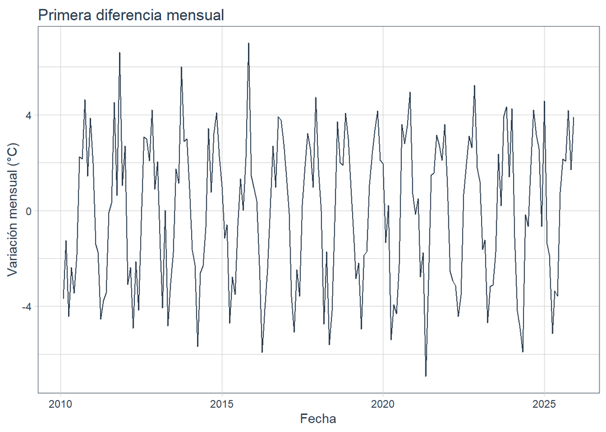

```r
datos_diferencias |>
  filter(!is.na(diferencia_1)) |>
  plot_time_series(
    .date_var    = fecha,
    .value       = diferencia_1,
    .title       = "Primera diferencia mensual",
    .x_lab       = "Fecha",
    .y_lab       = "Variación mensual (°C)",
    .smooth      = FALSE,
    .interactive = FALSE
  )
```

#### 4.3.2 Diferencia estacional de orden 12

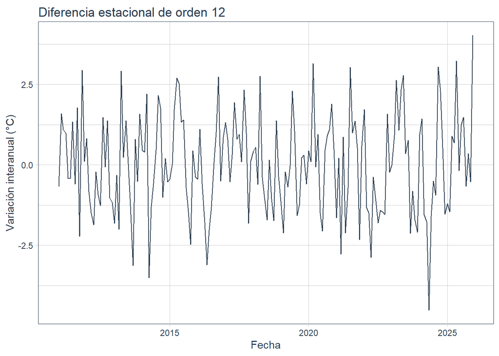

```r
datos_diferencias |>
  filter(!is.na(diferencia_12)) |>
  plot_time_series(
    .date_var    = fecha,
    .value       = diferencia_12,
    .title       = "Diferencia estacional de orden 12",
    .x_lab       = "Fecha",
    .y_lab       = "Variación interanual (°C)",
    .smooth      = FALSE,
    .interactive = FALSE
  )
```

**Interpretación.** Aplicamos dos transformaciones a la serie original de temperatura media mensual de Puerto Madryn: la primera diferencia y la diferencia estacional de orden 12.

La primera diferencia representa la variación de temperatura entre meses consecutivos. Su gráfico muestra oscilaciones positivas y negativas asociadas, principalmente, con el calentamiento y enfriamiento que ocurre a lo largo del año. Por lo tanto, esta transformación no elimina necesariamente la estacionalidad anual, ya que las variaciones mensuales también siguen un patrón estacional.

La diferencia estacional de orden 12 compara la temperatura media de cada mes con la correspondiente al mismo mes del año anterior. De esta manera, nos permite atenuar el componente estacional sistemático y observar las variaciones interanuales de temperatura.

A diferencia de la primera diferencia, la transformación estacional facilita la identificación de fluctuaciones que no responden directamente a la alternancia habitual entre estaciones cálidas y frías.

Los resultados previos del test ADF aportaron evidencia contra la presencia de una raíz unitaria ordinaria en las especificaciones con constante y con tendencia. Por ello, la primera diferenciación no puede considerarse una transformación obligatoria.

En esta etapa, ambas diferencias se utilizan con fines exploratorios y diagnósticos. Para evaluar sus propiedades de estacionariedad y dependencia temporal, se analizarán posteriormente los resultados del test ADF y las funciones de autocorrelación.

### 4.4 ADF sobre las series diferenciadas

Después de diferenciar, se vuelve a aplicar el test ADF para evaluar si las transformaciones producen una serie compatible con estacionariedad.

#### 4.4.1 ADF de la primera diferencia

```r
adf_diff1 <- datos_diferencias |>
  filter(!is.na(diferencia_1)) |>
  pull(diferencia_1) |>
  ur.df(
    type       = "drift",
    lags       = 12,
    selectlags = "AIC"
  )

summary(adf_diff1)
```

```
###############################################
# Augmented Dickey-Fuller Test Unit Root Test #
###############################################

Test regression drift


Call:
lm(formula = z.diff ~ z.lag.1 + 1 + z.diff.lag)

Residuals:
     Min       1Q   Median       3Q      Max
-3.10443 -0.71042 -0.00611  0.85790  2.56212

Coefficients:
              Estimate Std. Error t value Pr(>|t|)
(Intercept)   0.003991   0.089707   0.044  0.96456
z.lag.1      -6.750219   0.536612 -12.579  < 2e-16 ***
z.diff.lag1   5.170513   0.481422  10.740  < 2e-16 ***
z.diff.lag2   4.789714   0.425698  11.251  < 2e-16 ***
z.diff.lag3   4.275869   0.382337  11.184  < 2e-16 ***
z.diff.lag4   3.702309   0.336465  11.004  < 2e-16 ***
z.diff.lag5   3.098740   0.291654  10.625  < 2e-16 ***
z.diff.lag6   2.465620   0.250932   9.826  < 2e-16 ***
z.diff.lag7   1.886047   0.209725   8.993 5.27e-16 ***
z.diff.lag8   1.385252   0.168718   8.210 5.88e-14 ***
z.diff.lag9   0.821720   0.128986   6.371 1.78e-09 ***
z.diff.lag10  0.239426   0.075325   3.179  0.00177 **
---
Signif. codes:  0 '***' 0.001 '**' 0.01 '*' 0.05 '.' 0.1 ' ' 1

Residual standard error: 1.197 on 166 degrees of freedom
Multiple R-squared:  0.8166,    Adjusted R-squared:  0.8044
F-statistic: 67.19 on 11 and 166 DF,  p-value: < 2.2e-16


Value of test-statistic is: -12.5793 79.1201

Critical values for test statistics:
      1pct  5pct 10pct
tau2 -3.46 -2.88 -2.57
phi1  6.52  4.63  3.81
```

#### 4.4.2 ADF de la diferencia estacional

```r
adf_diff12 <- datos_diferencias |>
  filter(!is.na(diferencia_12)) |>
  pull(diferencia_12) |>
  ur.df(
    type       = "drift",
    lags       = 12,
    selectlags = "AIC"
  )

summary(adf_diff12)
```

```
###############################################
# Augmented Dickey-Fuller Test Unit Root Test #
###############################################

Test regression drift


Call:
lm(formula = z.diff ~ z.lag.1 + 1 + z.diff.lag)

Residuals:
    Min      1Q  Median      3Q     Max
-3.4339 -0.8417 -0.0467  0.8649  3.2896

Coefficients:
             Estimate Std. Error t value Pr(>|t|)
(Intercept)  -0.02501    0.09861  -0.254 0.800115
z.lag.1      -1.31840    0.20764  -6.349 2.31e-09 ***
z.diff.lag1   0.53112    0.19687   2.698 0.007759 **
z.diff.lag2   0.61133    0.18567   3.293 0.001231 **
z.diff.lag3   0.52433    0.17946   2.922 0.004005 **
z.diff.lag4   0.49256    0.17284   2.850 0.004974 **
z.diff.lag5   0.43539    0.16061   2.711 0.007474 **
z.diff.lag6   0.40091    0.14500   2.765 0.006392 **
z.diff.lag7   0.44192    0.12885   3.430 0.000775 ***
z.diff.lag8   0.59302    0.11389   5.207 6.06e-07 ***
z.diff.lag9   0.48541    0.10267   4.728 5.08e-06 ***
z.diff.lag10  0.39285    0.09268   4.239 3.86e-05 ***
z.diff.lag11  0.47595    0.07153   6.654 4.71e-10 ***
---
Signif. codes:  0 '***' 0.001 '**' 0.01 '*' 0.05 '.' 0.1 ' ' 1

Residual standard error: 1.27 on 154 degrees of freedom
Multiple R-squared:  0.5657,    Adjusted R-squared:  0.5319
F-statistic: 16.72 on 12 and 154 DF,  p-value: < 2.2e-16


Value of test-statistic is: -6.3494 20.1863

Critical values for test statistics:
      1pct  5pct 10pct
tau2 -3.46 -2.88 -2.57
phi1  6.52  4.63  3.81
```

**Interpretación.** Aplicamos el test de Dickey-Fuller aumentado (ADF) a la primera diferencia y a la diferencia estacional de orden 12, utilizando la especificación con constante (`drift`).

Para la primera diferencia obtuvimos un estadístico tau2 de -12,5793, inferior al valor crítico de -3,46 correspondiente al 1 % de significación. Por lo tanto, rechazamos la hipótesis nula de raíz unitaria ordinaria.

En la diferencia estacional de orden 12, el estadístico tau2 fue -6,3494, también inferior al valor crítico de -3,46. En consecuencia, se rechaza igualmente la hipótesis nula de raíz unitaria ordinaria al 1 %.

Estos resultados nos indican que ambas series transformadas presentan evidencia estadística contraria a la existencia de una raíz unitaria ordinaria.

Sin embargo, el rechazo de esta hipótesis no implica que las transformaciones hayan eliminado toda la dependencia temporal ni que las series resultantes constituyan procesos de ruido blanco.

Asimismo, el ADF convencional no permite descartar específicamente la presencia de raíces unitarias estacionales.

Considerando que el ADF aplicado a la serie original, con constante y con constante y tendencia, también permitió rechazar la hipótesis de raíz unitaria ordinaria al 5 %, estos resultados no justifican por sí solos la necesidad de aplicar una diferenciación adicional.

### 4.5 Autocorrelación de las series diferenciadas

Se analizan las funciones de autocorrelación (ACF) y autocorrelación parcial (PACF) de la primera diferencia y de la diferencia estacional de orden 12, con el propósito de identificar la dependencia temporal que permanece después de aplicar cada transformación.

#### 4.5.1 ACF de la primera diferencia

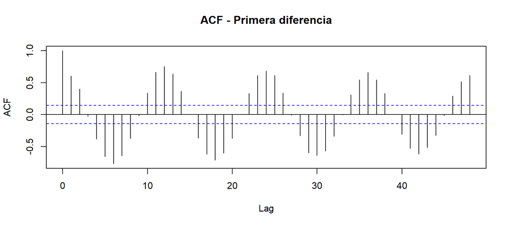

```r
acf(
  na.omit(datos_diferencias$diferencia_1),
  lag.max = 48,
  main = "ACF - Primera diferencia"
)
```

#### 4.5.2 PACF de la primera diferencia

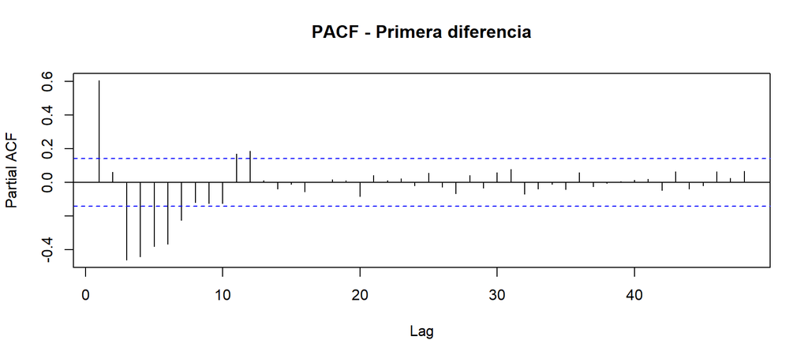

```r
pacf(
  na.omit(datos_diferencias$diferencia_1),
  lag.max = 48,
  main = "PACF - Primera diferencia"
)
```

#### 4.5.3 ACF de la diferencia estacional

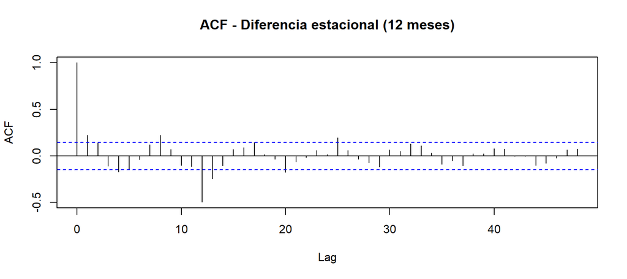

```r
acf(
  na.omit(datos_diferencias$diferencia_12),
  lag.max = 48,
  main = "ACF - Diferencia estacional (12 meses)"
)
```

#### 4.5.4 PACF de la diferencia estacional

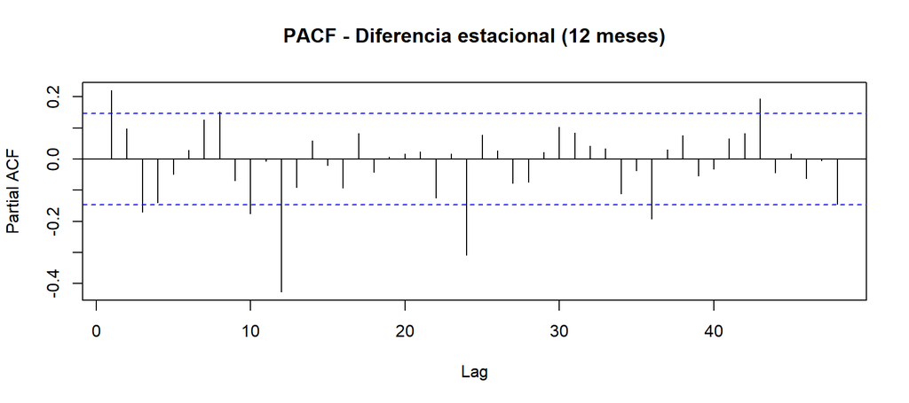

```r
pacf(
  na.omit(datos_diferencias$diferencia_12),
  lag.max = 48,
  main = "PACF - Diferencia estacional (12 meses)"
)
```

**Interpretación.**

En la primera diferencia, la ACF presenta oscilaciones periódicas pronunciadas, con autocorrelaciones positivas importantes en los rezagos 12, 24, 36 y 48, y negativas en rezagos intermedios, cercanos a 6, 18, 30 y 42 meses. Este comportamiento da cuenta que la diferenciación ordinaria no eliminó la estructura estacional anual de la serie original.

La PACF de la primera diferencia presenta una autocorrelación parcial positiva importante en el rezago 1, seguida de valores negativos en varios rezagos iniciales y algunos picos cercanos al rezago 12. Esto nos indica que permanece dependencia temporal, incluso después de considerar la relación con los rezagos intermedios.

En cambio, la ACF de la diferencia estacional de orden 12 presenta autocorrelaciones generalmente más pequeñas. Se destacan una autocorrelación positiva en el rezago 1, cercana a 0,22, y una autocorrelación negativa pronunciada en el rezago 12, aproximadamente igual a -0,50.

Esta última puede estar relacionada con la estructura introducida por la diferenciación estacional, dado que las diferencias separadas por 12 meses comparten una observación con signo opuesto.

La PACF de la diferencia estacional también presenta valores negativos destacados en los rezagos 12 y 24, lo que confirma que persiste dependencia temporal asociada con esos rezagos.

En conjunto, los gráficos muestran que la diferenciación estacional atenúa considerablemente el patrón periódico observado en la primera diferencia, aunque no elimina completamente la autocorrelación.

Por lo tanto, ninguna de las dos transformaciones puede considerarse ruido blanco a partir de estos diagnósticos. Los resultados del test de Ljung-Box permitirán complementar esta evaluación mediante un contraste formal de autocorrelación conjunta.

### 4.6 Test de Ljung-Box

El test de Ljung-Box permite contrastar la ausencia conjunta de autocorrelación hasta un determinado rezago.

La hipótesis nula es:

$$H_0: \rho_1 = \rho_2 = \cdots = \rho_m = 0$$

frente a la hipótesis alternativa:

$$H_1: \exists\, k \in \{1,\ldots,m\}
\text{ tal que } \rho_k \neq 0$$

donde $\rho_k$ representa la autocorrelación poblacional en el rezago $k$.

Para la serie mensual se consideran 24 rezagos, equivalentes a dos ciclos anuales completos.

```r
# Serie original
Box.test(
  datos_mensuales$temperatura,
  lag  = 24,
  type = "Ljung-Box"
)
```

```
    Box-Ljung test

data:  datos_mensuales$temperatura
X-squared = 1996.3, df = 24, p-value < 2.2e-16
```

```r
# Primera diferencia
Box.test(
  na.omit(datos_diferencias$diferencia_1),
  lag  = 24,
  type = "Ljung-Box"
)
```

```
    Box-Ljung test

data:  na.omit(datos_diferencias$diferencia_1)
X-squared = 1326.5, df = 24, p-value < 2.2e-16
```

```r
# Diferencia estacional
Box.test(
  na.omit(datos_diferencias$diferencia_12),
  lag  = 24,
  type = "Ljung-Box"
)
```

```
    Box-Ljung test

data:  na.omit(datos_diferencias$diferencia_12)
X-squared = 118.68, df = 24, p-value = 1.665e-14
```

**Interpretación.** Aplicamos el test de Ljung-Box a la serie original de temperatura media mensual de Puerto Madryn, a la primera diferencia y a la diferencia estacional de orden 12, considerando 24 rezagos.

Para la serie original obtuvimos un estadístico Q de 1996,30, con un valor p inferior a 2,2 × 10^-16. En consecuencia, rechazamos la hipótesis nula de ausencia conjunta de autocorrelación al nivel de significación del 5 %. Este resultado es consistente con la marcada dependencia estacional identificada en la ACF de la serie original.

En la primera diferencia, el estadístico Q fue 1326,50, con un valor p inferior a 2,2 × 10^-16. También se rechaza la hipótesis nula, lo que indica que la diferenciación ordinaria no eliminó la dependencia temporal. Este resultado coincide con las oscilaciones periódicas observadas en su función de autocorrelación.

Por su parte, la diferencia estacional de orden 12 presentó un estadístico Q de 118,68 y un valor p de 1,665 × 10^-14. Aunque el estadístico es considerablemente menor que el de las otras series, también rechazamos la hipótesis nula al 5 %.

Este resultado es coherente con la ACF de la diferencia estacional, donde la mayoría de las autocorrelaciones son relativamente pequeñas, pero persisten valores destacados, particularmente en el rezago 12.

La disminución del estadístico Q resulta compatible con una atenuación de la dependencia temporal después de la diferenciación estacional. Pero, la comparación debe interpretarse con cautela, porque las transformaciones modifican la longitud y la estructura de las series.

Los resultados nos permiten concluir que las tres series presentan autocorrelación estadísticamente significativa. Por lo tanto, ninguna muestra un comportamiento compatible con ruido blanco según este contraste.

## 5 Partición cronológica de entrenamiento y prueba

Con 192 observaciones mensuales, se calcula el tamaño aproximado del conjunto de prueba:

$$n_{\text{prueba}}
= 192 \times 0{,}20
= 38{,}4$$

Seleccionamos 38 observaciones para el conjunto de prueba, equivalentes aproximadamente al 19,79 % de la serie. Las 154 observaciones restantes se destinan al entrenamiento.

```r
n_total <- nrow(datos_mensuales)
n_test  <- round(n_total * 0.20)

splits <- datos_mensuales |>
  time_series_split(
    date_var   = fecha,
    assess     = n_test,
    cumulative = TRUE
  )

train_data <- training(splits)
test_data  <- testing(splits)

# Verificación de tamaños y proporciones
nrow(train_data)
```

```
[1] 154
```

```r
nrow(test_data)
```

```
[1] 38
```

```r
nrow(train_data) / n_total * 100
```

```
[1] 80.20833
```

```r
nrow(test_data)  / n_total * 100
```

```
[1] 19.79167
```

```r
# Períodos cubiertos por cada conjunto
range(train_data$fecha)
```

```
[1] "2010-01-01" "2022-10-01"
```

```r
range(test_data$fecha)
```

```
[1] "2022-11-01" "2025-12-01"
```

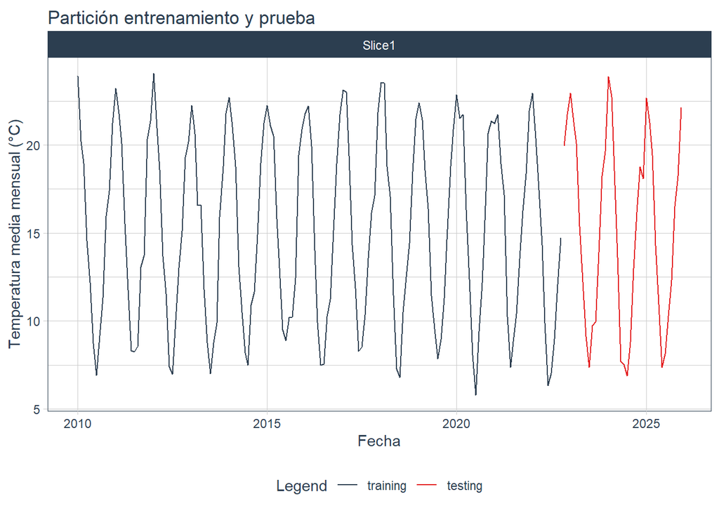

```r
# Visualización de la partición
splits |>
  tk_time_series_cv_plan() |>
  plot_time_series_cv_plan(
    .date_var    = fecha,
    .value       = temperatura,
    .title       = "Partición entrenamiento y prueba",
    .x_lab       = "Fecha",
    .y_lab       = "Temperatura media mensual (°C)",
    .interactive = FALSE
  )
```

**Interpretación.** Dividimos la serie de temperatura media mensual de Puerto Madryn cronológicamente en dos conjuntos: entrenamiento y prueba, respetando el orden temporal de las observaciones.

El conjunto de entrenamiento contiene 154 observaciones mensuales, correspondientes al período enero de 2010 a octubre de 2022, lo que representa aproximadamente el 80,21 % del total.

El conjunto de prueba comprende las 38 observaciones restantes, desde noviembre de 2022 hasta diciembre de 2025, equivalentes al 19,79 % de la serie.

A diferencia de una partición aleatoria, con la separación cronológica conservamos la secuencia temporal de los datos y evitamos utilizar observaciones futuras para ajustar modelos destinados a predecir períodos posteriormente.

El conjunto de prueba abarca 38 meses, equivalentes a tres ciclos anuales completos y dos meses adicionales, lo que nos permitirá evaluar posteriormente predicciones en diferentes momentos del ciclo estacional.

En esta etapa no se ajustan modelos ni se realizan pronósticos. La partición se incorpora únicamente como preparación para la siguiente unidad, dedicada a la modelización de series temporales.

## 6 Continuaremos con la Unidad 2 la segunda semena de Serie de Tiempo.